# HW5_COIT_DAVID

**To see if the strange behavior is related to the way the date is represented in this data, I repeat the boosting and bagging performed above, this time with the date information included.**

```r
# Redo above boosting / bagging, but with categorical month / day values included

# load Ozone dataset as "ozone2"
# This dataset was assembled with the goal of predictine the daily maximum one hour average ozone2 reading
# which is imported as "V4"
data(Ozone)
ozone2 <- Ozone
ozone2 <- na.omit(ozone2)
rm(Ozone)

# Rename columns based on online annotation
# https://rdrr.io/cran/mlbench/man/Ozone.html
names(ozone2) <- c("Month",
                  "DayOfMonth",
                  "DayOfWeek",
                  "DailyMaxOzone",
                  "PressVandenberg",
                  "WindSpeedLAX",
                  "HumidityLAX",
                  "TempSandburg",
                  "TempElMonte",
                  "InvHeightLAX",
                  "PressGradLAXDag",
                  "InvTempLAX",
                  "VisibilityLAX")
```

```r
# training / testing split
set.seed(1618)
train_size <- floor(0.75 * nrow(ozone2))
train_pos <- sample(seq_len(nrow(ozone2)), size = train_size)
train <- ozone2[train_pos, ]
test <- ozone2[-train_pos, ]
```

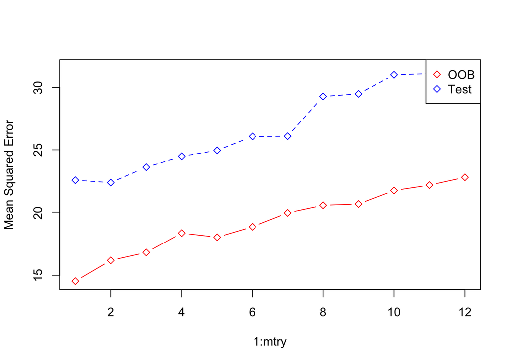

```r
# random forest with categorical date info included
set.seed(1618)
rf.ozone2 = randomForest(DailyMaxOzone~.,
                        data = ozone2,
                        subset = train_pos,
                        na.action = na.omit)

m = ncol(ozone2)-1

##Try a range of values for m (number of variables selected at random at each split)
oob.err = double(m)
test.err = double(m)

#In a loop of mtry from 1 to 6, fit the randomForest to the train dataset
# Sample all possbile m's

for(mtry in 1:m){
  fit = randomForest(DailyMaxOzone~.,
                     data = ozone2,
                     subset=train_pos,
                     mtry=mtry,
                     ntree = 350,
                     na.action = na.roughfix)
  oob.err[mtry] = fit$mse[350] ##extract Mean-squared-error
  pred = predict(fit, ozone2[-train_pos,]) #predict on test dataset
  test.err[mtry] = with(ozone2[-train_pos,], mean( (DailyMaxOzone-pred)^2 )) #compute test error
}

# Visualize mean squared error vs variables sampled per split
matplot(1:mtry, cbind(test.err, oob.err), pch = 23, col = c("red", "blue"), type = "b", ylab="Mean Squared Error")
legend("topright", legend = c("OOB", "Test"), pch = 23, col = c("red", "blue"))
```

```r
print( (max(oob.err)-min(oob.err)) / min(oob.err) )
```

```
## [1] 0.4072715
```

**Here we see our surprising result again, this time with a larger relative range in the observed MSE. This lends support to the idea that the date information as represented is just adding noise to the model input.**

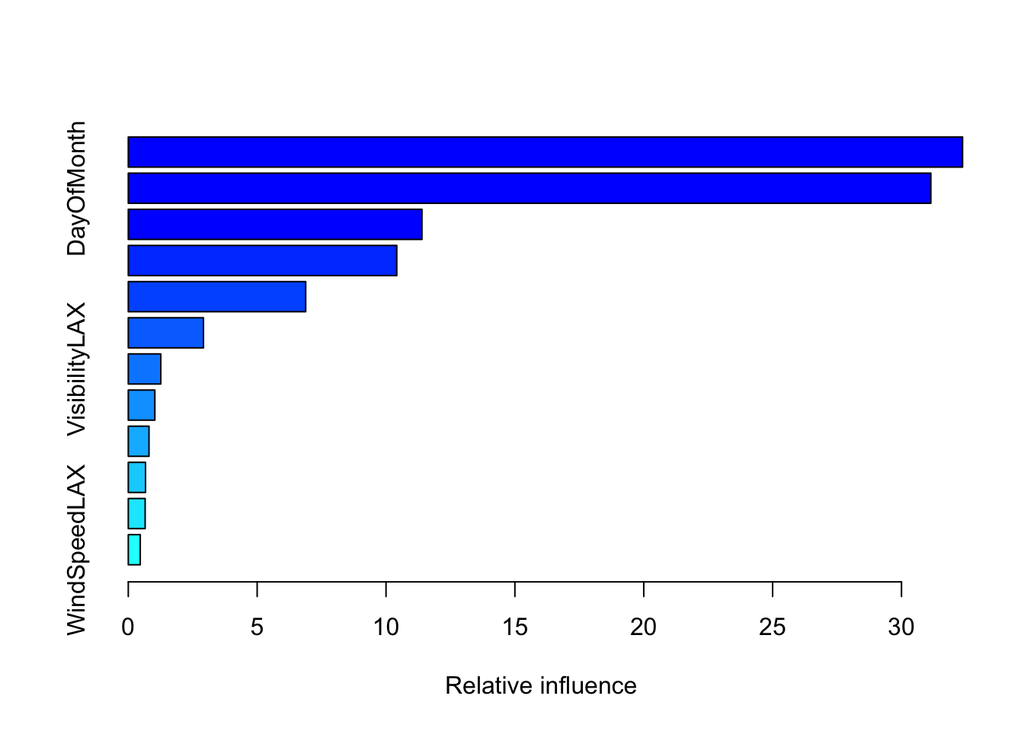

```
##                             var    rel.inf
## TempElMonte         TempElMonte 32.3695949
## DayOfMonth           DayOfMonth 31.1386231
## TempSandburg       TempSandburg 11.3941905
## Month                     Month 10.4167146
## InvTempLAX           InvTempLAX  6.8834481
## InvHeightLAX       InvHeightLAX  2.9170634
## VisibilityLAX     VisibilityLAX  1.2601994
## PressGradLAXDag PressGradLAXDag  1.0302122
## DayOfWeek             DayOfWeek  0.8036678
## HumidityLAX         HumidityLAX  0.6683246
## PressVandenberg PressVandenberg  0.6540286
## WindSpeedLAX       WindSpeedLAX  0.4639328
```

```r
set.seed(1618)
#Gradient Boosting Model, ozone data with categorical data info
boost.ozone2 = gbm(DailyMaxOzone ~ .,
                  data = train,
                  distribution = "gaussian",
                  n.trees = 10000,
                  shrinkage = 0.01,
                  interaction.depth = 4)

#Variable Importance Plot
summary(boost.ozone2)
```

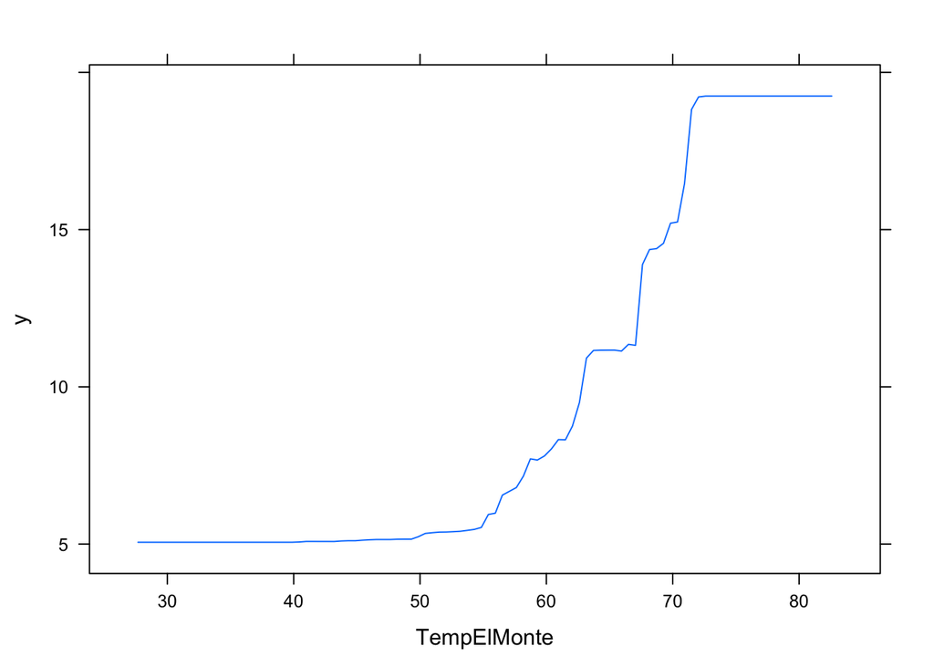

```r
#Visualize important variables of interest
plot(boost.ozone2,i="TempElMonte")
```

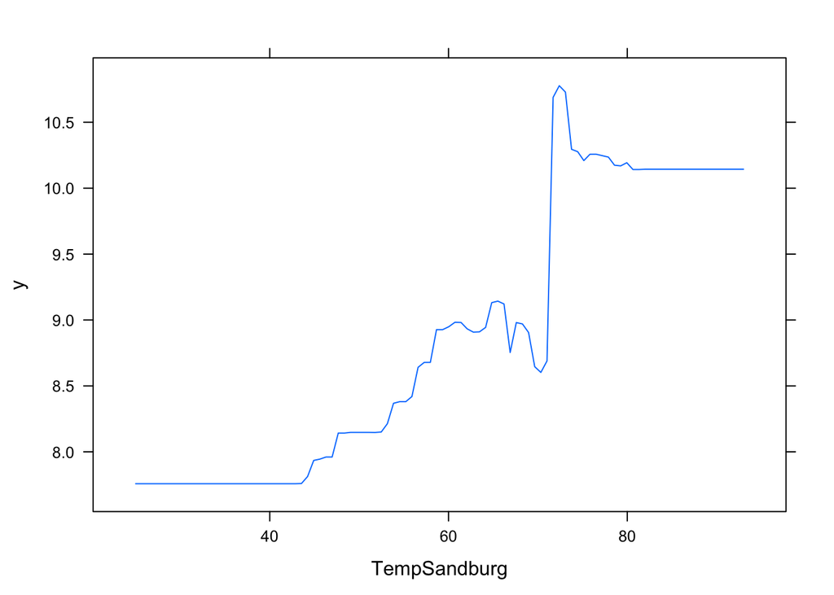

```r
plot(boost.ozone2,i="TempSandburg")
```

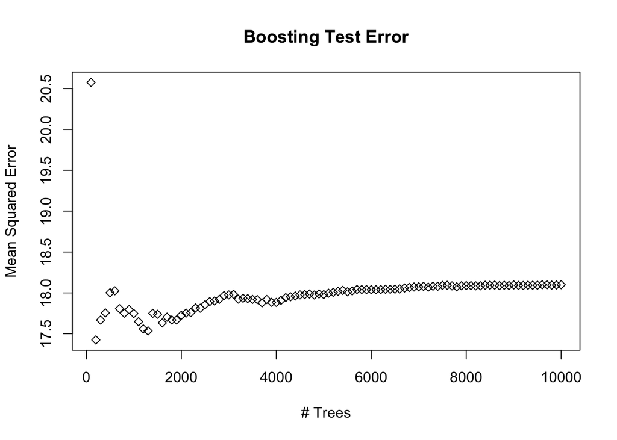

```r
#Predict on test set
n.trees = seq(from = 100, to = 10000, by = 100)
predmat = predict(boost.ozone2, newdata = ozone2[-train_pos,], n.trees = n.trees)

#Visualize Boosting Error Plot
boost.err = with(ozone2[-train_pos,], apply( (predmat - DailyMaxOzone)^2, 2, mean) )
plot(n.trees, boost.err, pch = 23, ylab = "Mean Squared Error", xlab = "# Trees", main = "Boosting Test Error")
abline(h = min(test.err), col = "red")
```

### Tree-Based Regression, Ozone Data

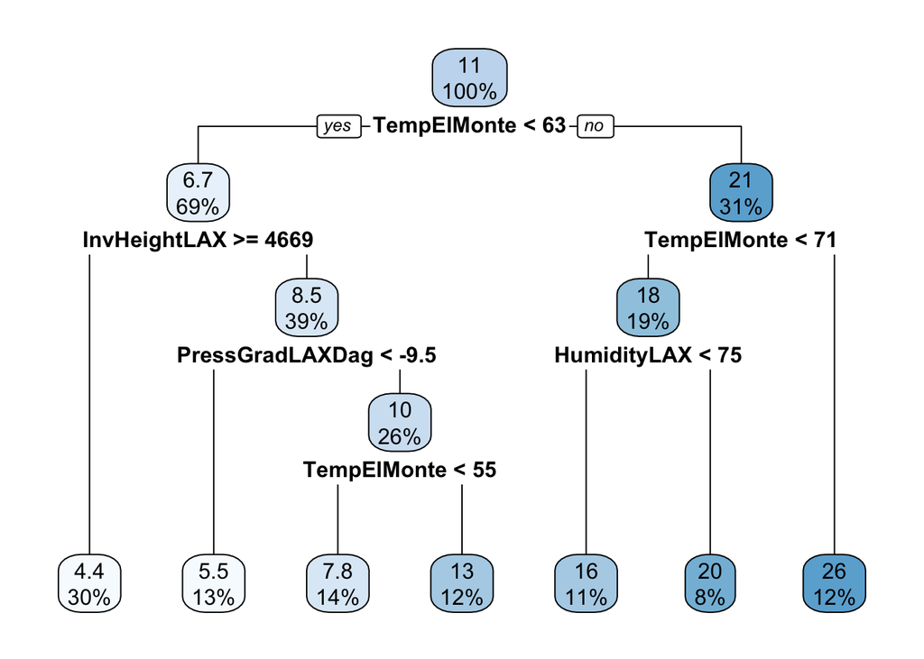

```r
#Regression tree based method
# Tree with categorical day / month columns
set.seed(1618)
tree.ozone <-  rpart(
  formula = DailyMaxOzone ~ .,
  data = ozone[train_pos,],
  method = "anova"
)
rpart.plot(tree.ozone, roundint = FALSE)
```

```r
# test model
pred <- predict(tree.ozone, newdata = ozone[-train_pos,])
test.err = with(ozone[-train_pos,], mean( (DailyMaxOzone-pred)^2 )) #compute test error

# Calculate RMSE of model predictions on test set
ozoneRMSE = rmse(ozone[-train_pos,]$DailyMaxOzone, pred)
print(ozoneRMSE)
```

```
## [1] 4.738082
```

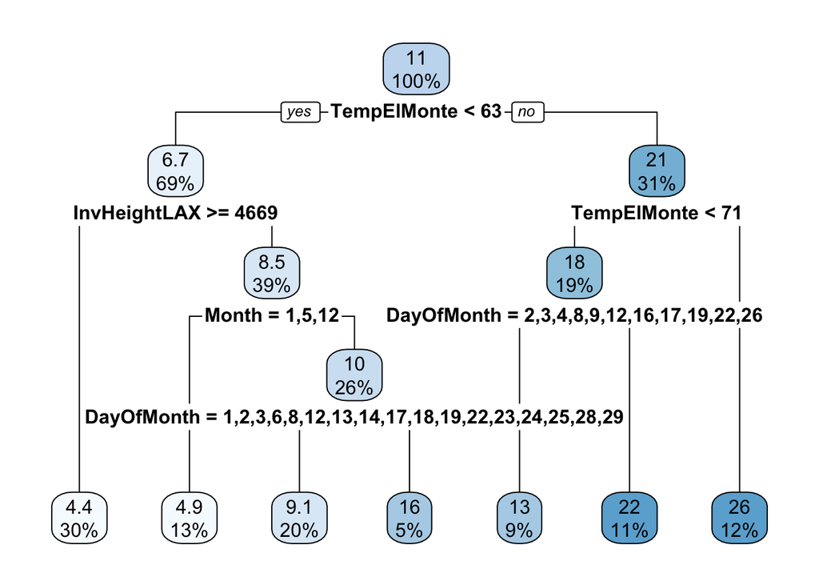

```r
# Regression ree with categorical day / month columns retained

set.seed(1618)
tree.ozone2 <-  rpart(
  formula = DailyMaxOzone ~ .,
  data = ozone2[train_pos,],
  method = "anova"
)
rpart.plot(tree.ozone2, roundint = FALSE)
```

```r
# test model
pred <- predict(tree.ozone2, newdata = ozone2[-train_pos,])
test.err = with(ozone2[-train_pos,], mean( (DailyMaxOzone-pred)^2 )) #compute test error

# Calculate RMSE of model predictions on test set
ozone2RMSE = rmse(ozone2[-train_pos,]$DailyMaxOzone, pred)
print(ozone2RMSE)
```

```
## [1] 5.854712
```

**The fact that the RMSE of this regression tree is greater with the categorical date variables included is not surprising. I think some transformation of the date data might prove useful, such as transforming the month and day into a distance from the summer solstice (thus giving the same value to late December / early January eg). However such an exploration is outside the scope of this assignment.**

### Concrete Compressive Strength Data

**I wanted to try these methods on a dataset that didn’t have this suspected time-dependent behavior with an odd organization of the time data. To that end, I repeat the work from above, but with a more straightforward regression task provide by the concrete compressive strength dataset from the UCI machine learning repository.**

```r
# Import the concrete compressive strength dataset from the UCI ML repo
# The goal of this dataset is to predict the compressive strength of concrete based
# on its material composition and age
URL <- "http://archive.ics.uci.edu/ml/machine-learning-databases/concrete/compressive/"
source_file_name = ("Concrete_Data.xls")
path = paste0(URL,source_file_name)

concrete <- read.xls(path,
                 header = TRUE)

names(concrete) <- c("CementComp1",
                 "BFSlag",
                 "FlyAsh",
                 "Water",
                 "Superplasticity",
                 "CoarseAgg",
                 "FineAgg",
                 "Age",
                 "CompStr")
```

```r
# concrete training / testing split
set.seed(1618)
train_size <- floor(0.75 * nrow(concrete))
train_pos <- sample(seq_len(nrow(concrete)), size = train_size)
train <- concrete[train_pos, ]
test <- concrete[-train_pos, ]
```

### Tree-Based Regression, Concrete Data

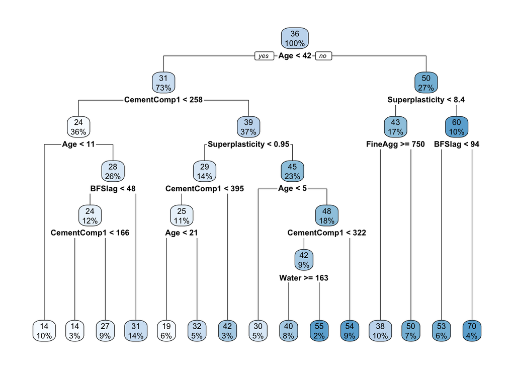

```r
# Tree with categorical day / month columns
set.seed(1618)
tree.concrete <-  rpart(
  formula = CompStr ~ .,
  data = concrete[train_pos,],
  method = "anova"
)
rpart.plot(tree.concrete, roundint = FALSE)
```

```r
# test model
pred <- predict(tree.concrete, newdata = concrete[-train_pos,])
test.err = with(concrete[-train_pos,], mean( (CompStr-pred)^2 )) #compute test error

# Calculate RMSE of model predictions on test set
concreteRMSE = rmse(concrete[-train_pos,]$CompStr, pred)
print(concreteRMSE)
```

```
## [1] 8.779187
```

**The tree regression performed above suggests that concrete age is the most important predictor of compressive strength. After age, the amount of cement component 1 in kg/m3.**

### Boosting and Bagging, Concrete Data

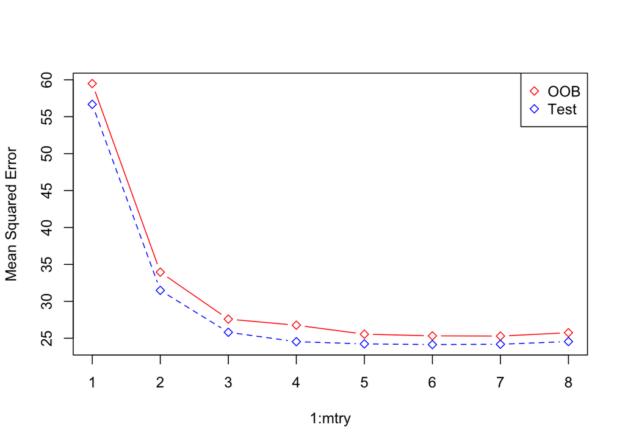

```r
set.seed(1618)
# Random Forest

rf.concrete = randomForest(CompStr~.,
                        data = concrete,
                        subset = train_pos,
                        na.action = na.omit)

m = ncol(concrete)-1
##Try a range of values for m (number of variables selected at random at each split)
oob.err = double(m)
test.err = double(m)

#In a loop of mtry from 1 to 6, fit the randomForest to the train dataset
# Sample all possbile m's

for(mtry in 1:m){
  fit = randomForest(CompStr~.,
                     data = concrete,
                     subset=train_pos,
                     mtry=mtry,
                     ntree = 350,
                     na.action = na.roughfix)
  oob.err[mtry] = fit$mse[350] ##extract Mean-squared-error
  pred = predict(fit, concrete[-train_pos,]) #predict on test dataset
  test.err[mtry] = with(concrete[-train_pos,], mean( (CompStr-pred)^2 )) #compute test error
}

# Visualize mean squared error vs variables sampled per split
matplot(1:mtry, cbind(test.err, oob.err), pch = 23, col = c("red", "blue"), type = "b", ylab="Mean Squared Error")
legend("topright", legend = c("OOB", "Test"), pch = 23, col = c("red", "blue"))
```

**In contrast with the example above with the ozone data, the mean square error vs. M behavior we see here is much more what we expect to see. Because this is a much more straightforward regression task without the possible time-dependent behavior of the variables, we don’t observe the increasing MSE.**

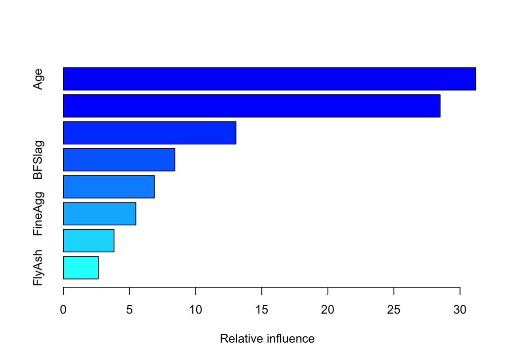

```
##                             var   rel.inf
## Age                         Age 31.182980
## CementComp1         CementComp1 28.501818
## Water                     Water 13.053605
## BFSlag                   BFSlag  8.427577
## Superplasticity Superplasticity  6.879616
## FineAgg                 FineAgg  5.481878
## CoarseAgg             CoarseAgg  3.828937
## FlyAsh                   FlyAsh  2.643590
```

```r
set.seed(1618)
#Gradient Boosting Model
boost.concrete = gbm(CompStr ~ .,
                  data = train,
                  distribution = "gaussian",
                  n.trees = 10000,
                  shrinkage = 0.01,
                  interaction.depth = 4)

#Variable Importance Plot
summary(boost.concrete)
```